# Ejercicio clustering jerárquico

Roi Naveiro, Victor Gallego

8/5/2019

## Clustering jerárquico

Utilizaremos el dataset votes.repub, consistente en una tabla con el porcentaje de votos dados al candidato republicano en elecciones presidenciales desde 1856 a 1976. La fuente del dataset es

S. Peterson (1973): A Statistical History of the American Presidential Elections. New York: Frederick Ungar Publishing Co. Data from 1964 to 1976 is from R. M. Scammon, American Votes 12, Congressional Quarterly.

1. Obtenemos el dataset desde la librería cluster

```r
votes.repub <- cluster::votes.repub
```

2. Explorar el dataset. Observar que contiene 50 filas (1 por estado) y 31 columnas (1 por cada elección desde 1856 hasta 1976)

Representar gráficamente el porcentaje de voto para cada estado a lo largo de los años.

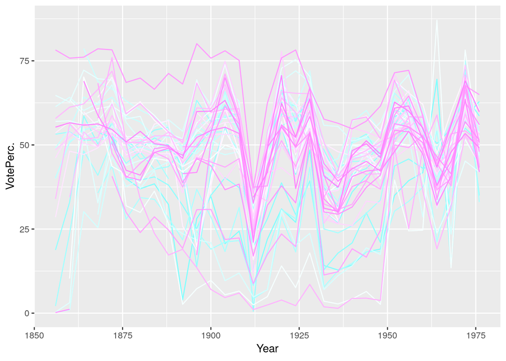

```r
library(ggplot2)
votes <- reshape2::melt(t(votes.repub))

votes$Var1 <- sub(pattern = "X",
                replacement = "", x=votes$Var1)
votes$Var1 <- strtoi(votes$Var1)
colnames(votes) <- c('Year',  'State', 'VotePerc.')

ggplot(votes, aes(x=Year)) +
  geom_line(aes(y=VotePerc., col=State)) +
  theme(legend.position = "none")+
  scale_color_manual(values=cm.colors(50))
```

```r
#
```

3. Calcular la matriz de distancias usando la función dist Previamente, aplicar la transformación angular (arcsin(sqrt(x/100))) a los datos.

Representar la matriz de distancias utilizando la función image

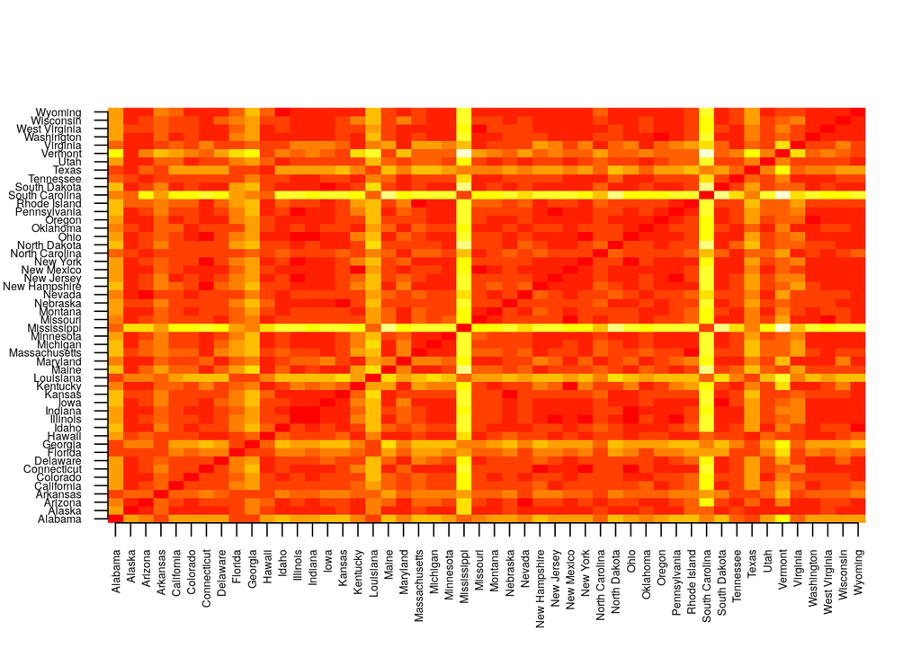

```r
asinTransform <- function(p) { asin(sqrt(p/100.)) }

d_votes <- dist(asinTransform(votes.repub))

dim <- nrow(votes.repub)
image(1:dim, 1:dim, as.matrix(d_votes), axes = FALSE, xlab="", ylab="")

axis(1, 1:dim, rownames(votes.repub), cex.axis = 0.5, las=3)
axis(2, 1:dim, rownames(votes.repub), cex.axis = 0.5, las=1)
```

4. Realiza un clustering jerárquico usando link completo mediante la función hclust Explorar el objeto resultante

```r
hc_votes <- hclust(d_votes, method = "complete")
```

5. Representa el dendrograma usando la función plot y as.dendrogram del objeto anterior

¿Cuáles son los estados más parecidos?

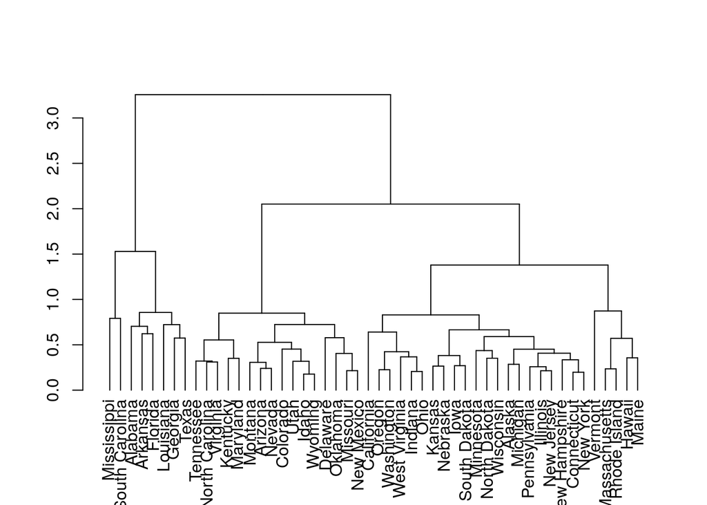

```r
dend <- as.dendrogram(hc_votes)
plot(dend)
```

6. Ahora utilizaremos la librería dendextend para tener más flexibilidad con los dendrogramas. Usando la función color_branches, obtén dos clusters

```r
#devtools::install_version("fpc", version = "2.1-4", repos = "http://cran.us.r-project.org")
#install.packages('dendextend')
library(dendextend)
```

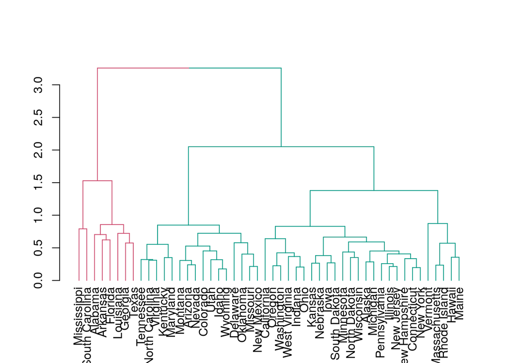

```r
dend <- color_branches(dend, k=2)
plot(dend)
```

7. Con la librería gplots, representaremos además un heatmap para comprobar el dendograma

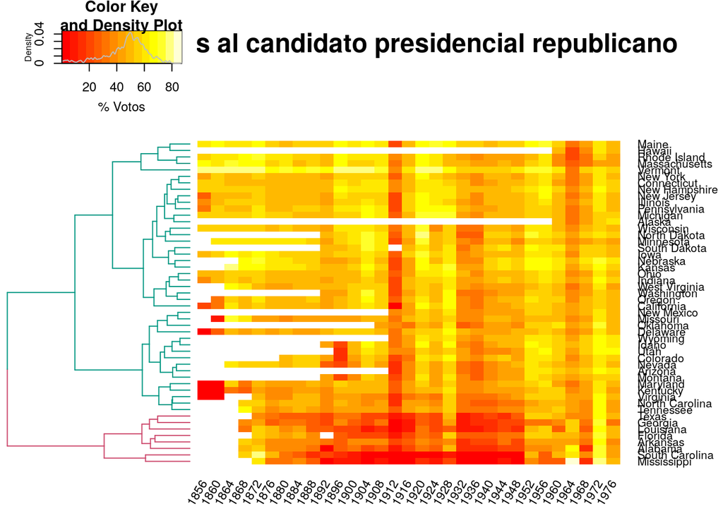

```r
#install.packages('gplots')
library(gplots)
heatmap.2(as.matrix(votes.repub),
          main = "Votos al candidato presidencial republicano",
          srtCol = 60,
          dendrogram = "row",
          Rowv = dend,
          Colv = "NA", # this to make sure the columns are not ordered
          trace="none",
          margins =c(3,6),
          key.xlab = "% Votos",
          labCol = votes$Year,
          denscol = "grey",
          density.info = "density"
         )
```

8. Teniendo en cuenta el siguiente gráfico de correlaciones entre dendogramas

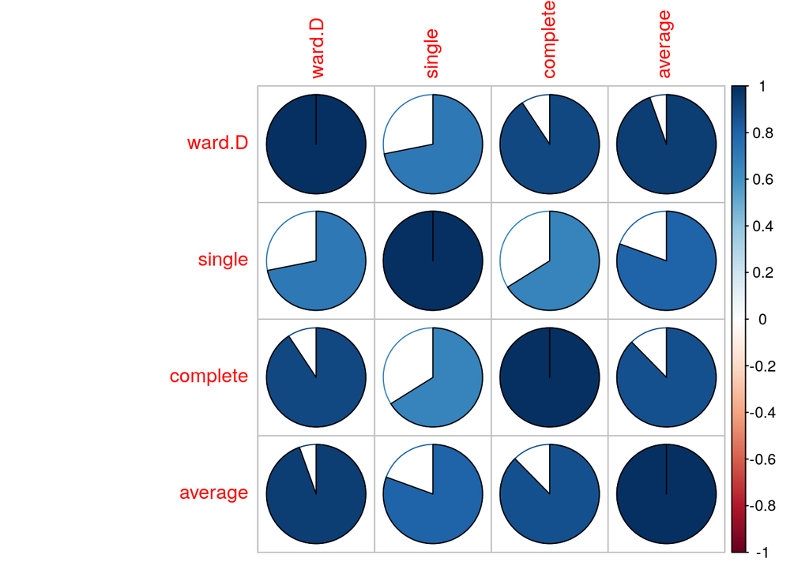

```r
hclust_methods <- c("ward.D", "single", "complete", "average")
votes.repub_dendlist <- dendlist()

for(i in seq_along(hclust_methods)) {
   tmp_dend <- votes.repub %>% asinTransform %>% dist %>% hclust(method = hclust_methods[i]) %>% as.dendrogram
   votes.repub_dendlist <- dendlist(votes.repub_dendlist, tmp_dend)
}
names(votes.repub_dendlist) <- hclust_methods


corrplot::corrplot(cor.dendlist(votes.repub_dendlist), "pie", "full")
```

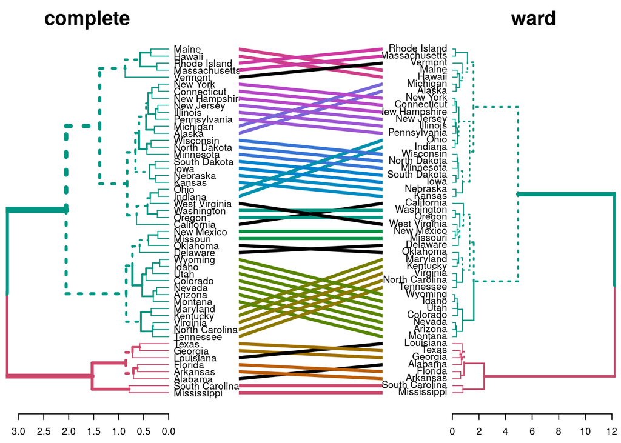

```r
dend_com <- color_branches(as.dendrogram(hclust(d_votes, method = "complete")), k=2)
dend_com <- rotate(dend_com, labels(dend))
dend_ward <- color_branches(as.dendrogram(hclust(d_votes, method = "ward.D")), k=2)
dend_ward <- rotate(dend_ward, labels(dend))

dends <- dendlist(complete = dend_com, ward = dend_ward)
tanglegram(dends, margin_inner = 6)
```

Ahora repetimos lo mismo pero con el método más distinto al completo

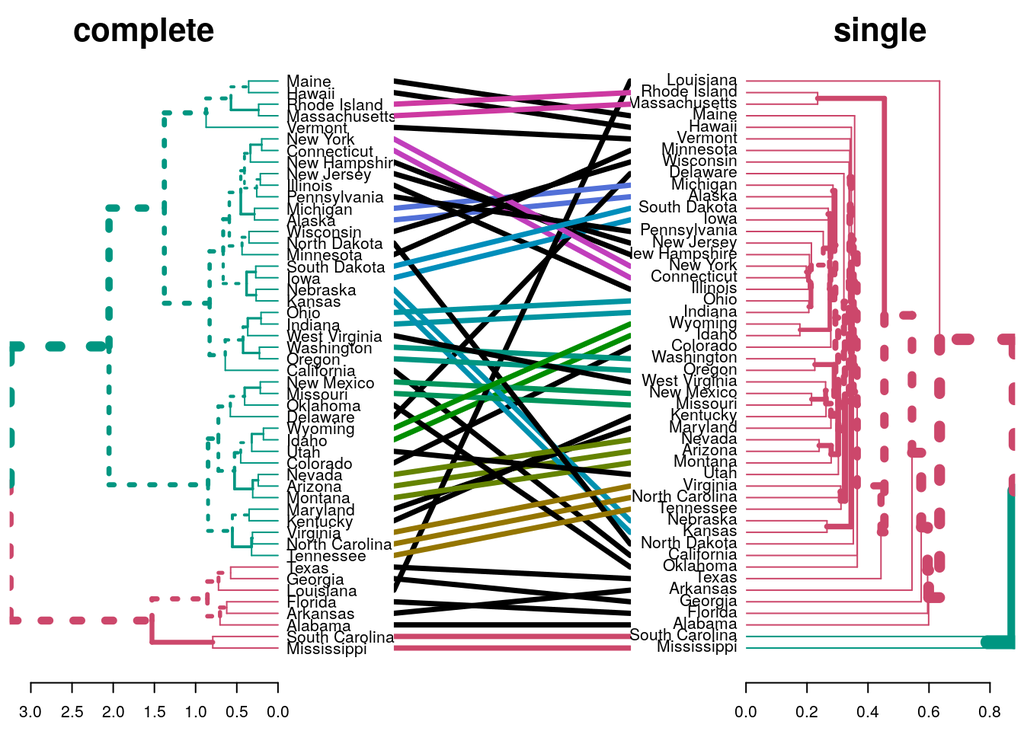

```r
dend_com <- color_branches(as.dendrogram(hclust(d_votes, method = "complete")), k=2)
dend_com <- rotate(dend_com, labels(dend))
dend_sing <- color_branches(as.dendrogram(hclust(d_votes, method = "single")), k=2)
dend_sing <- rotate(dend_sing, labels(dend))

dends <- dendlist(complete = dend_com, single = dend_sing)
tanglegram(dends, margin_inner = 6)
```